# **SuperKart Sales Prediction**

## **Data Preprocessing**

### **Feature Engineering**

**A store that has been in the business for a long duration is more trustworthy than the newly established one. On the other hand, older stores may sometimes lack infrastructure if proper attention is not given. So let us calculate the current age of the store and incorporate that into our model.**

```python
# Outlet Age
data["Store_Age_Years"] = 2022 - data.Store_Establishment_Year
```

**We have 16 different product types in our dataset. So let us make two broad categories, perishables and non perishables, in order to reduce the number of product types.**

```python
perishables = [
    "Dairy",
    "Meat",
    "Fruits and Vegetables",
    "Breakfast",
    "Breads",
    "Seafood",
]
```

```python
def change(x):
    if x in perishables:
        return "Perishables"
    else:
        return "Non Perishables"


data.Product_Type.apply(change)
```

```
0       Non Perishables
1           Perishables
2       Non Perishables
3       Non Perishables
4       Non Perishables
             ...
8758    Non Perishables
8759    Non Perishables
8760    Non Perishables
8761    Non Perishables
8762    Non Perishables
Name: Product_Type, Length: 8763, dtype: object
```

```python
change1 = []
for i in range(0, len(data)):
    if data.Product_Type[i] in perishables:
        change1.append("Perishables")
    else:
        change1.append("Non Perishables")
```

```python
data["Product_Type_Category"] = pd.Series(change1)
```

```python
data.head()
```

|  | Product_Weight | Product_Sugar_Content | Product_Allocated_Area | Product_Type | Product_MRP | Store_Id | Store_Establishment_Year | Store_Size | Store_Location_City_Type | Store_Type | Product_Store_Sales_Total | Product_Id_char | Store_Age_Years | Product_Type_Category |
| --- | --- | --- | --- | --- | --- | --- | --- | --- | --- | --- | --- | --- | --- | --- |
| 0 | 12.66 | Low Sugar | 0.027 | Frozen Foods | 117.08 | OUT004 | 2009 | Medium | Tier 2 | Supermarket Type2 | 2842.40 | FD | 13 | Non Perishables |
| 1 | 16.54 | Low Sugar | 0.144 | Dairy | 171.43 | OUT003 | 1999 | Medium | Tier 1 | Departmental Store | 4830.02 | FD | 23 | Perishables |
| 2 | 14.28 | Regular | 0.031 | Canned | 162.08 | OUT001 | 1987 | High | Tier 2 | Supermarket Type1 | 4130.16 | FD | 35 | Non Perishables |
| 3 | 12.10 | Low Sugar | 0.112 | Baking Goods | 186.31 | OUT001 | 1987 | High | Tier 2 | Supermarket Type1 | 4132.18 | FD | 35 | Non Perishables |
| 4 | 9.57 | No Sugar | 0.010 | Health and Hygiene | 123.67 | OUT002 | 1998 | Small | Tier 3 | Food Mart | 2279.36 | NC | 24 | Non Perishables |

### **Outlier Check**

- Let's check for outliers in the data.

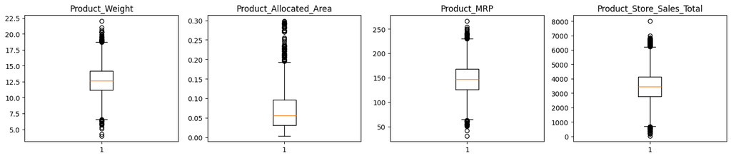

```python
# Outlier detection using boxplot
numeric_columns = data.select_dtypes(include=np.number).columns.tolist()
numeric_columns.remove("Store_Establishment_Year")
numeric_columns.remove("Store_Age_Years")


plt.figure(figsize = (15, 12))

for i, variable in enumerate(numeric_columns):
    plt.subplot(4, 4, i + 1)
    plt.boxplot(data[variable], whis = 1.5)
    plt.tight_layout()
    plt.title(variable)

plt.show()
```

**Observations:**

- There are quite a few outliers in the data.
- However, we will not treat them as they are proper values.

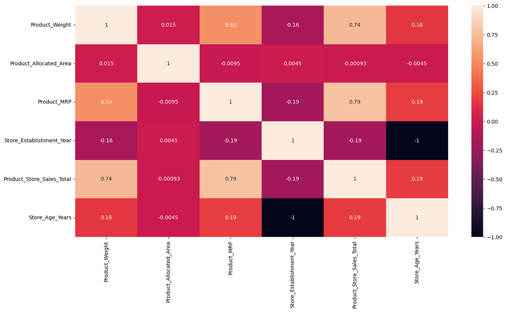

```python
plt.figure(figsize = (16, 8))
sns.heatmap(data.corr(numeric_only = True), annot = True)
plt.show()
```

**Observation:**

### **Data Preparation for modeling**

- We want to forecast the Product_Store_Sales_Total.
- Before we proceed to build a model, we'll have to encode categorical features and drop the unnecessary columns
- We'll split the data into train and test to be able to evaluate the model that we build on the train data.

```python
data = data.drop(["Product_Type", "Store_Id", "Store_Establishment_Year"], axis = 1)
```

```python
data = pd.get_dummies(
    data,
    columns = data.select_dtypes(include = ["object", "category"]).columns.tolist(),
    drop_first = True,
)
```

```python
# Separating features and the target column
X = data.drop(["Product_Store_Sales_Total"], axis = 1)
y = data["Product_Store_Sales_Total"]
```

```python
X = sm.add_constant(X)
```

```python
# Splitting the data into train and test sets in 70:30 ratio
X_train, X_test, y_train, y_test = train_test_split(
    X, y, test_size = 0.30, random_state = 1)
```

### **Check for Multicollinearity**

We will use the Variance Inflation Factor (VIF), to check if there is multicollinearity in the data.

Features having a VIF score > 5 will be dropped/treated till all the features have a VIF score < 5

```python
X_train1 = X_train.astype(float)
y_train1 = y_train.astype(float)

from statsmodels.stats.outliers_influence import variance_inflation_factor

# Function to check VIF
def checking_vif(train):
    vif = pd.DataFrame()
    vif["feature"] = train.columns

    # Calculating VIF for each feature
    vif["VIF"] = [
        variance_inflation_factor(train.values, i) for i in range(len(train.columns))
    ]
    return vif

print(checking_vif(X_train1)) #made change to X_train1
```

```
                              feature       VIF
0                               const  0.000000
1                      Product_Weight  1.752928
2              Product_Allocated_Area  1.001184
3                         Product_MRP  1.885058
4                     Store_Age_Years       inf
5      Product_Sugar_Content_No Sugar       inf
6       Product_Sugar_Content_Regular  1.088506
7                   Store_Size_Medium       inf
8                    Store_Size_Small       inf
9     Store_Location_City_Type_Tier 2       inf
10    Store_Location_City_Type_Tier 3       inf
11               Store_Type_Food Mart       inf
12       Store_Type_Supermarket Type1       inf
13       Store_Type_Supermarket Type2       inf
14                 Product_Id_char_FD  2.774371
15                 Product_Id_char_NC       inf
16  Product_Type_Category_Perishables  1.217690
```

**Observations:**

- The VIF of Product_Weight, Product_Allocation_Area, Product_MRP, Product_Id_char_FD are less.
- The VIF for dummy variables can be ignored which is expected that they would have a high VIF.
- But the continuous variables should not have high VIF.

```python
X_train1 = X_train1.drop('Store_Age_Years',axis = 1)

X_test = X_test.drop('Store_Age_Years',axis = 1)
```

```python
from statsmodels.stats.outliers_influence import variance_inflation_factor

# Function to check VIF
def checking_vif(train):
    vif = pd.DataFrame()
    vif["feature"] = train.columns

    # Calculating VIF for each feature
    vif["VIF"] = [
        variance_inflation_factor(train.values, i) for i in range(len(train.columns))
    ]
    return vif


print(checking_vif(X_train1))
```

```
                              feature       VIF
0                               const  0.000000
1                      Product_Weight  1.752928
2              Product_Allocated_Area  1.001184
3                         Product_MRP  1.885058
4      Product_Sugar_Content_No Sugar       inf
5       Product_Sugar_Content_Regular  1.088506
6                   Store_Size_Medium       inf
7                    Store_Size_Small       inf
8     Store_Location_City_Type_Tier 2       inf
9     Store_Location_City_Type_Tier 3       inf
10               Store_Type_Food Mart       inf
11       Store_Type_Supermarket Type1       inf
12       Store_Type_Supermarket Type2       inf
13                 Product_Id_char_FD  2.774371
14                 Product_Id_char_NC       inf
15  Product_Type_Category_Perishables  1.217690
```

## **Building Models**

Let's create a function to calculate the performance metrics for our regression model so that we don't need to use the same code repeatedly.

```python
from sklearn.metrics import r2_score, mean_absolute_percentage_error, mean_absolute_error, mean_squared_error

# Model Performance on test and train data
def model_pref(olsmodel, x_train, x_test):

    # In-sample Prediction
    y_pred_train = olsmodel.predict(x_train)
    y_observed_train = y_train

    # Prediction on test data
    y_pred_test = olsmodel.predict(x_test)
    y_observed_test = y_test

    print(
        pd.DataFrame(
            {
                "Data": ["Train", "Test"],
                "RMSE": [
                    np.sqrt(mean_squared_error(y_pred_train, y_observed_train)),
                    np.sqrt(mean_squared_error(y_pred_test, y_observed_test)),
                ],
                "MAE": [
                    mean_absolute_error(y_pred_train, y_observed_train),
                    mean_absolute_error(y_pred_test, y_observed_test),
                ],

                "r2": [
                    r2_score(y_pred_train, y_observed_train),
                    r2_score(y_pred_test, y_observed_test),
                ],
            }
        )
    )
```

```python
X_train1 = X_train1.astype(float)
y_train1 = y_train.astype(float)

# Create the model
model1 = sm.OLS(y_train1, X_train1).fit()

# Get the model summary
model1.summary()
```

OLS Regression Results

| Dep. Variable: | Product_Store_Sales_Total | R-squared: | 0.824 |
| --- | --- | --- | --- |
| Model: | OLS | Adj. R-squared: | 0.823 |
| Method: | Least Squares | F-statistic: | 2860. |
| Date: | Sat, 18 Jan 2025 | Prob (F-statistic): | 0.00 |
| Time: | 07:35:20 | Log-Likelihood: | -46132. |
| No. Observations: | 6134 | AIC: | 9.229e+04 |
| Df Residuals: | 6123 | BIC: | 9.236e+04 |
| Df Model: | 10 |  |  |
| Covariance Type: | nonrobust |  |  |

|  | coef | std err | t | P>\|t\| | [0.025 | 0.975] |
| --- | --- | --- | --- | --- | --- | --- |
| const | 176.6077 | 42.659 | 4.140 | 0.000 | 92.982 | 260.234 |
| Product_Weight | 135.0943 | 3.436 | 39.318 | 0.000 | 128.359 | 141.830 |
| Product_Allocated_Area | -139.5679 | 118.876 | -1.174 | 0.240 | -372.608 | 93.472 |
| Product_MRP | 12.8696 | 0.254 | 50.702 | 0.000 | 12.372 | 13.367 |
| Product_Sugar_Content_No Sugar | 16.0039 | 12.324 | 1.299 | 0.194 | -8.155 | 40.163 |
| Product_Sugar_Content_Regular | 30.8608 | 13.284 | 2.323 | 0.020 | 4.819 | 56.902 |
| Store_Size_Medium | 394.3947 | 26.547 | 14.856 | 0.000 | 342.353 | 446.436 |
| Store_Size_Small | -383.1731 | 5.776 | -66.339 | 0.000 | -394.496 | -371.850 |
| Store_Location_City_Type_Tier 2 | -308.1516 | 8.855 | -34.801 | 0.000 | -325.510 | -290.794 |
| Store_Location_City_Type_Tier 3 | -383.1731 | 5.776 | -66.339 | 0.000 | -394.496 | -371.850 |
| Store_Type_Food Mart | -383.1731 | 5.776 | -66.339 | 0.000 | -394.496 | -371.850 |
| Store_Type_Supermarket Type1 | 165.3861 | 17.762 | 9.311 | 0.000 | 130.566 | 200.206 |
| Store_Type_Supermarket Type2 | -473.5378 | 17.176 | -27.570 | 0.000 | -507.208 | -439.867 |
| Product_Id_char_FD | 0.3932 | 21.936 | 0.018 | 0.986 | -42.609 | 43.396 |
| Product_Id_char_NC | 16.0039 | 12.324 | 1.299 | 0.194 | -8.155 | 40.163 |
| Product_Type_Category_Perishables | 7.7111 | 13.233 | 0.583 | 0.560 | -18.231 | 33.653 |

| Omnibus: | 1745.262 | Durbin-Watson: | 1.987 |
| --- | --- | --- | --- |
| Prob(Omnibus): | 0.000 | Jarque-Bera (JB): | 46497.082 |
| Skew: | 0.775 | Prob(JB): | 0.00 |
| Kurtosis: | 16.399 | Cond. No. | 2.46e+20 |

Notes:  
[1] Standard Errors assume that the covariance matrix of the errors is correctly specified.  
[2] The smallest eigenvalue is 2.31e-33. This might indicate that there are  
strong multicollinearity problems or that the design matrix is singular.

```python
# Checking model1 performance
model_pref(model1, X_train1, X_test)
```

```
    Data        RMSE         MAE        r2
0  Train  446.667654  262.110666  0.785927
1   Test  446.685287  266.690587  0.790208
```

**Observations:**

- The Train and the Test scores are very close to each other so we can say the model is not overfitting.
- However, the Test score is slightly better than the Train score. So, we might be able to get better performance if we increase the complexity of the model.

### **Drop insignificant variables (variables with p-value > 0.05) from the above model and create the regression model again.**

```python
X_train1 = X_train1.drop(["Product_Type_Category_Perishables", "Product_Id_char_FD"], axis = 1)
```

```python
X_test1 = X_test.drop(["Product_Type_Category_Perishables", "Product_Id_char_FD"], axis = 1)
```

```python
X_train1 = X_train1.astype(float)
y_train1 = y_train.astype(float)

# Create the model
model2 = sm.OLS(y_train, X_train1).fit()

# Get the model summary
model2.summary()
```

OLS Regression Results

| Dep. Variable: | Product_Store_Sales_Total | R-squared: | 0.824 |
| --- | --- | --- | --- |
| Model: | OLS | Adj. R-squared: | 0.823 |
| Method: | Least Squares | F-statistic: | 3576. |
| Date: | Sat, 18 Jan 2025 | Prob (F-statistic): | 0.00 |
| Time: | 07:35:20 | Log-Likelihood: | -46132. |
| No. Observations: | 6134 | AIC: | 9.228e+04 |
| Df Residuals: | 6125 | BIC: | 9.234e+04 |
| Df Model: | 8 |  |  |
| Covariance Type: | nonrobust |  |  |

|  | coef | std err | t | P>\|t\| | [0.025 | 0.975] |
| --- | --- | --- | --- | --- | --- | --- |
| const | 179.0666 | 40.949 | 4.373 | 0.000 | 98.793 | 259.340 |
| Product_Weight | 135.0918 | 3.435 | 39.323 | 0.000 | 128.357 | 141.827 |
| Product_Allocated_Area | -140.3752 | 118.852 | -1.181 | 0.238 | -373.367 | 92.616 |
| Product_MRP | 12.8703 | 0.254 | 50.727 | 0.000 | 12.373 | 13.368 |
| Product_Sugar_Content_No Sugar | 14.1944 | 7.933 | 1.789 | 0.074 | -1.358 | 29.747 |
| Product_Sugar_Content_Regular | 30.7219 | 13.272 | 2.315 | 0.021 | 4.704 | 56.740 |
| Store_Size_Medium | 395.6741 | 25.835 | 15.316 | 0.000 | 345.029 | 446.319 |
| Store_Size_Small | -382.7595 | 5.395 | -70.953 | 0.000 | -393.335 | -372.184 |
| Store_Location_City_Type_Tier 2 | -307.8490 | 8.636 | -35.648 | 0.000 | -324.778 | -290.920 |
| Store_Location_City_Type_Tier 3 | -382.7595 | 5.395 | -70.953 | 0.000 | -393.335 | -372.184 |
| Store_Type_Food Mart | -382.7595 | 5.395 | -70.953 | 0.000 | -393.335 | -372.184 |
| Store_Type_Supermarket Type1 | 166.1521 | 17.353 | 9.575 | 0.000 | 132.135 | 200.169 |
| Store_Type_Supermarket Type2 | -474.0011 | 17.074 | -27.762 | 0.000 | -507.472 | -440.530 |
| Product_Id_char_NC | 14.1944 | 7.933 | 1.789 | 0.074 | -1.358 | 29.747 |

| Omnibus: | 1744.629 | Durbin-Watson: | 1.987 |
| --- | --- | --- | --- |
| Prob(Omnibus): | 0.000 | Jarque-Bera (JB): | 46526.548 |
| Skew: | 0.775 | Prob(JB): | 0.00 |
| Kurtosis: | 16.403 | Cond. No. | 1.78e+34 |

Notes:  
[1] Standard Errors assume that the covariance matrix of the errors is correctly specified.  
[2] The smallest eigenvalue is 4.4e-61. This might indicate that there are  
strong multicollinearity problems or that the design matrix is singular.

```python
# Checking model2 performance
model_pref(model2, X_train1, X_test1)
```

```
    Data        RMSE         MAE        r2
0  Train  446.681336  262.125308  0.785911
1   Test  446.780252  266.790089  0.790113
```

**Observations:**

### **Checking the below linear regression assumptions**

1. **Mean of residuals should be 0**
2. **No Heteroscedasticity**
3. **Linearity of variables**
4. **Normality of error terms**

### **1. Check for mean residuals**

```python
residuals = model2.resid

np.mean(residuals)
```

```
7.361361746596404e-12
```

**Observation:**

- The mean of residuals is very close to 0. Hence, the corresponding assumption is satisfied.

### **2. Check for homoscedasticity**

- Homoscedasticity - If the residuals are symmetrically distributed across the regression line, then the data is said to be homoscedastic.
- Heteroscedasticity- - If the residuals are not symmetrically distributed across the regression line, then the data is said to be heteroscedastic. In this case, the residuals can form a funnel shape or any other non-symmetrical shape.
- We'll use `Goldfeldquandt Test` to test the following hypothesis with alpha = 0.05:
  - Null hypothesis: Residuals are homoscedastic
  - Alternate hypothesis: Residuals have heteroscedastic

```python
from statsmodels.stats.diagnostic import het_white

from statsmodels.compat import lzip

import statsmodels.stats.api as sms
```

```python
name = ["F statistic", "p-value"]

test = sms.het_goldfeldquandt(y_train, X_train1)

lzip(name, test)
```

```
[('F statistic', 0.9832189770563932), ('p-value', 0.6800664494252238)]
```

**Observation:**

- Since p-value > 0.05, we cannot reject the Null Hypothesis that the residuals are homoscedastic and the corresponding assumption is satisfied.

### **3. Linearity of variables**

It states that the predictor variables must have a linear relation with the dependent variable.

To test the assumption, we'll plot residuals and the fitted values on a plot and ensure that residuals do not form a strong pattern. They should be randomly and uniformly scattered on the x-axis.

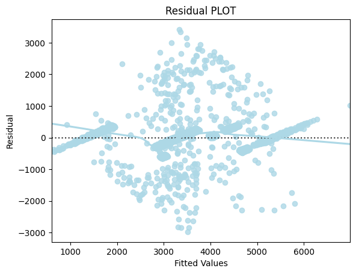

```python
# Predicted values
fitted = model2.fittedvalues

# sns.set_style("whitegrid")
sns.residplot(x = fitted, y = residuals, color = "lightblue", lowess = True)

plt.xlabel("Fitted Values")

plt.ylabel("Residual")

plt.title("Residual PLOT")

plt.show()
```

**Observation:**

### **4. Normality of error terms**

The residuals should be normally distributed.

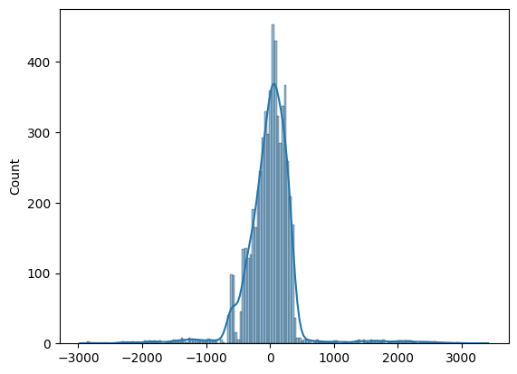

```python
# Plot histogram of residuals
sns.histplot(residuals, kde = True)
```

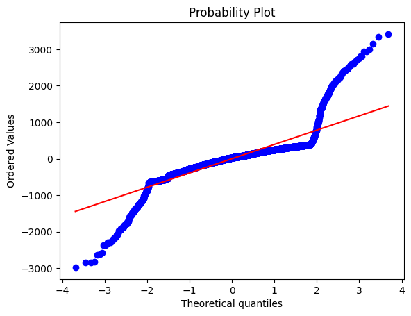

```python
# Plot q-q plot of residuals
import pylab

import scipy.stats as stats

stats.probplot(residuals, dist = "norm", plot = pylab)

plt.show()
```

**Observation:**

### **Apply cross validation to improve the model and evaluate it using different evaluation metrics**

Let's check the performance of the model using the cross-validation technique from the scikit-learn library and see if the performance on the train and the test data is comparable to what we are getting after cross-validating the data.

```python
# Import the required function

from sklearn.model_selection import cross_val_score

# Build the regression model and cross-validate
linearregression = LinearRegression()

cv_Score11 = cross_val_score(linearregression, X_train, y_train, cv = 10)
cv_Score12 = cross_val_score(linearregression, X_train, y_train, cv = 10,
                             scoring = 'neg_mean_squared_error')


print("RSquared: %0.3f (+/- %0.3f)" % (cv_Score11.mean(), cv_Score11.std() * 2))
print("Mean Squared Error: %0.3f (+/- %0.3f)" % (-1*cv_Score12.mean(), cv_Score12.std() * 2))
```

```
RSquared: 0.823 (+/- 0.045)
Mean Squared Error: 200712.689 (+/- 64085.512)
```

**Observation:**

- After applying cross-validation the model score has improved. We can compare it by the evaluation metric scores.

## **Actionable Insights and Business Recommendations**

- We can use this prediction model to predict the total sales that will be done by SuperKart in the next quarter.
- The model explains around 79% of the variation in the data.
- **OUT004** - OUT004, which is of Supermarket Type2, located in a Tier 2 city and having store size as medium, is performing well. SuperKart can look to increase the size of this store from medium to high. They can also look to set up stores in this type of city having comparable socio-economic conditions in order to expand their business and reach.
- **OUT002** - OUT002, being a food mart in a Tier 3 city and having small store size, is also performing well. SuperKart can look to upgrade its size or target similar cities for business expansion.
- **OUT001** - OUT001 which is a store of Supermarket Type 1, located in a Tier 2 city and having store size as high is not performing upto the mark. SuperKart can look to look build new marketing strategies (maybe give attractive discounts and offers) in this store in order to attract more customers.
- **OUT003** - Similar approach can be taken to increase the business of OUT003 which is a Departmental store in a Tier 1 city and having store size as medium. It is the premium store of the company where most of the costly goods are sold, so the correct set of audience should be targetted.
- Daily needs like fruits and vegetables and snack foods are the biggest contributors to the revenue across all the stores. So SuperKart should look to maintain the inventory of these products properly and ensure that these products never face a shortage.

**Additional information that can be collected to gain better insights -**

- Customers' details like age and gender can be incorporated in this model so that the company gets to know their target audience well and can build their sales strategies according to that.
- The company should also keep a watch for the number of festive occasions present in a quarter so that they can strategize their inventory accordingly.